# HW2 Solutions

Alexander Cardazzi

Quarantine, 2020

**[All Materials Here](https://sites.google.com/view/alex-cardazzi/home/using-r)**

Use the sharks dataset for this HW. This should be more slightly more difficult than the first homework. You will likely have to do some googling, but I have hinted some functions to look into. After each line, try to view the data to see if the results of your code match what you wanted it to do.

- Make a time series plot of the number of attacks per year.
- Make a frequency distribution for the ages of those being attacked.
- Plot the locations of the shark attacks. Color the attacks by whether or not the attack was fatal. Once this works, try and get fancy with the `scales` package.
- Make a new binary variable for whether the attack was on the west coast. (hint, `?ifelse`)
- Make a binary variable for if the attack was unprovoked. (hint, `?ifelse`)
- Make a binary variable for if there was “No injury” or a “minor” injury (hint, look for these inside the text of the Injury column. hint, `?grepl`)
- Make a binary variable for if the person attacked was male. You may have to use both the Sex column and the Name column.
- Make summary stats for the sharks data.
- Use the binary variable for no injury or minor injury as your dependent variable. Given an attack, what factors lead to more serious injuries? Run a few regressions, have fun with it.
- Is there a variable that significantly changes the sample size of your regressions? Why
- Do you think these missing ages are [missing at random](https://www.ncbi.nlm.nih.gov/books/NBK493614/)?
- Are serious injuries more or less likely given missingness for the variable?

```r
library("stargazer")
library("scales")
rm(list = ls())

sharks <- read.csv("C:/Users/alexc/Desktop/Empirical Workshop/data/sharks.csv", stringsAsFactors = FALSE)
#View(sharks)
```

### 1 - Make a time series plot of the number of attacks per year.

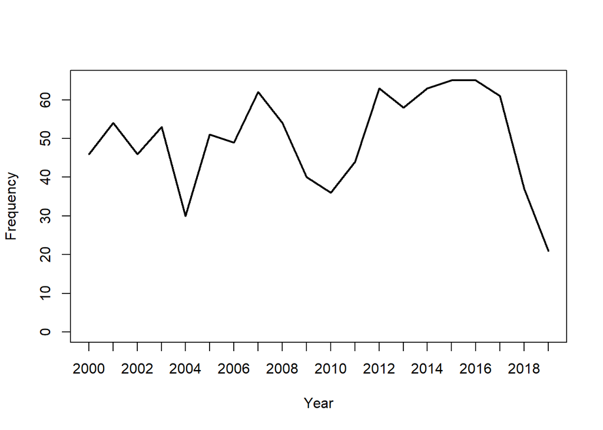

```r
timeSeries <- table(sharks$Year)
plot(timeSeries, type = "l", ylab = "Frequency", xlab = "Year")
```

### 2 - Make a frequency distribution for the ages of those being attacked.

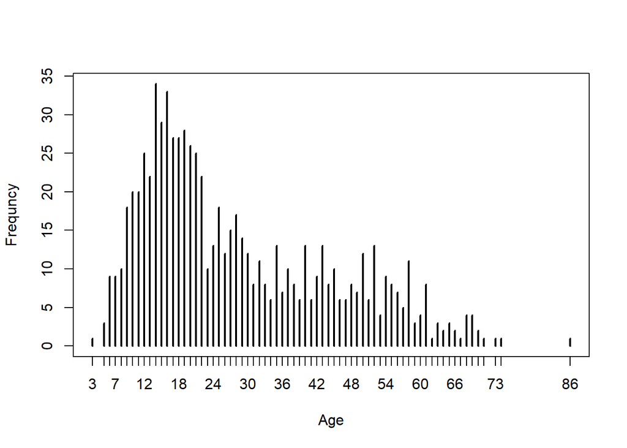

```r
plot(table(as.numeric(sharks$Age)), ylab = "Frequncy", xlab = "Age")
```

### 3 - Plot the locations of the shark attacks. Color the attacks by whether or not the attack was fatal.

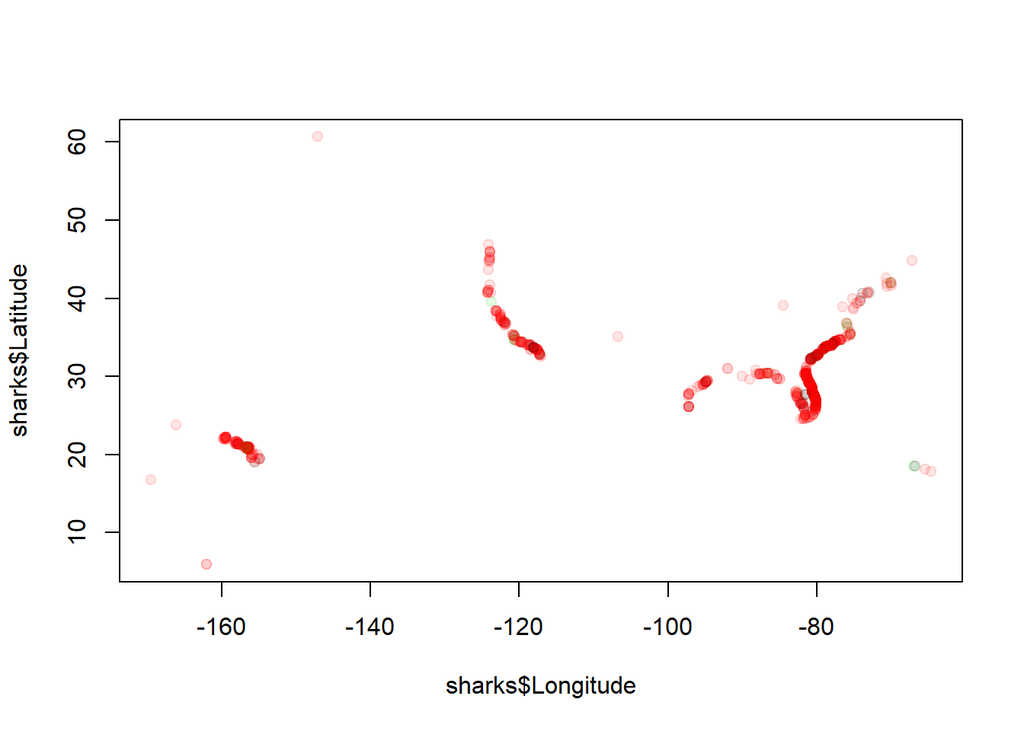

```r
sharks$fatalColor <- as.numeric(as.factor(sharks$Fatal..Y.N.))
#plot(sharks$Longitude, sharks$Latitude, pch = 19, col = c(1,2))
plot(sharks$Longitude, sharks$Latitude,
     col = alpha(sharks$fatalColor, .1), pch = 19)
```

### 4 - Make a new binary variable for whether the attack was on the west coast.

```r
sharks$westCoast <- ifelse(sharks$Longitude < -100, 1, 0)
table(sharks$westCoast)
```

```
##
##   0   1
## 761 237
```

### 5 - Make a binary variable for if the attack was unprovoked.

```r
table(sharks$Type)
```

```
##
##             Invalid            Provoked        Questionable
##                  61                  57                   4
##        Sea Disaster Under investigation          Unprovoked
##                   2                   1                 837
##          Watercraft
##                  36
```

```r
sharks$unprovoked <- ifelse(sharks$Type == "Unprovoked", 1, 0)
table(sharks$unprovoked)
```

```
##
##   0   1
## 161 837
```

### 6 - Make a binary variable for if there was “No injury” or a “minor” injury

```r
sharks$severe_injury <- ifelse(grepl("No injury", sharks$Injury) | grepl("minor", tolower(sharks$Injury)), 0, 1)
table(sharks$severe_injury)
```

```
##
##   0   1
## 229 769
```

### 7 - Make a binary variable for if the person attacked was male.

```r
sharks$Sex <- ifelse(sharks$Name == "female", "F", ifelse(sharks$Name == "male", "M", sharks$Sex))
sharks$Sex <- ifelse(sharks$Sex == "", NA, sharks$Sex)
sharks$male <- ifelse(is.na(sharks$Sex), NA, ifelse(sharks$Sex == "M", 1, 0))
table(sharks$male)
```

```
##
##   0   1
## 224 755
```

### 8 - Make summary stats for the sharks data.

```r
stargazer(sharks, type = "text")
```

```
##
## =============================================================================
## Statistic            N    Mean    St. Dev.   Min    Pctl(25) Pctl(75)   Max
## -----------------------------------------------------------------------------
## Year                998 2,009.572  5.588    2,000    2,005    2,014    2,019
## original.order      998 5,297.683 640.417   4,239   4,739.2   5,842    6,427
## Latitude            998  29.611    5.116    5.889    27.355   32.819  60.691
## Longitude           998  -94.624   26.284  -169.534 -96.548  -80.327  -64.621
## Maximum.Temperature 980  82.559    7.805    42.200   79.100   87.900  98.500
## Minimum.Temperature 980  68.324    9.093    23.100   63.750   74.600  84.800
## Temperature         980  75.079    7.986    35.900   71.900   80.500  91.400
## Precipitation       980   0.154    0.653    0.000    0.000    0.000   11.300
## Precipitation.Cover 980   7.362    16.883   0.000    0.000    8.300   100.000
## Wind.Speed          979  14.200    4.556    0.000    11.200   16.400  44.700
## Wind.Gust           126  32.548    7.686    4.500    30.000   36.425  57.500
## Visibility          975   9.233    1.147    1.500    8.800    10.000  12.800
## fatalColor          998   1.964    0.277      1        2        2        3
## westCoast           998   0.237    0.426      0        0        0        1
## unprovoked          998   0.839    0.368      0        1        1        1
## severe_injury       998   0.771    0.421      0        1        1        1
## male                979   0.771    0.420    0.000    1.000    1.000    1.000
## -----------------------------------------------------------------------------
```